# Part I - Ford GoBike System Data Exploration

## by (Imen Bakir)

- Introduction
- Preliminary Wrangling
- Cleaning data
- Univariate Exploration
- Bivariate Exploration
- Multivariate Exploration
- Conclusion

## Introduction

This data set includes information about individual rides made in a bike-sharing system covering the greater San Francisco Bay area. There are approximately 183412 rides made in a bike-sharing system covering the greater "San Francisco Bay" area.

## Preliminary Wrangling

In this step we will import necessary libraries wich will help us in our analysis and explore our data in order to make it clean and tidy ann ready for visual exploration.

```python
# import all packages and set plots to be embedded inline
import numpy as np
import pandas as pd
import matplotlib.pyplot as plt
import seaborn as sb

%matplotlib inline
```

```python
df = pd.read_csv('Ford_GoBike_System_Data.csv')
df.head(10)
```

|  | duration_sec | start_time | end_time | start_station_id | start_station_name | start_station_latitude | start_station_longitude | end_station_id | end_station_name | end_station_latitude | end_station_longitude | bike_id | user_type | member_birth_year | member_gender | bike_share_for_all_trip |
| --- | --- | --- | --- | --- | --- | --- | --- | --- | --- | --- | --- | --- | --- | --- | --- | --- |
| 0 | 52185 | 2019-02-28 17:32:10.1450 | 2019-03-01 08:01:55.9750 | 21.0 | Montgomery St BART Station (Market St at 2nd St) | 37.789625 | -122.400811 | 13.0 | Commercial St at Montgomery St | 37.794231 | -122.402923 | 4902 | Customer | 1984.0 | Male | No |
| 1 | 42521 | 2019-02-28 18:53:21.7890 | 2019-03-01 06:42:03.0560 | 23.0 | The Embarcadero at Steuart St | 37.791464 | -122.391034 | 81.0 | Berry St at 4th St | 37.775880 | -122.393170 | 2535 | Customer | NaN | NaN | No |
| 2 | 61854 | 2019-02-28 12:13:13.2180 | 2019-03-01 05:24:08.1460 | 86.0 | Market St at Dolores St | 37.769305 | -122.426826 | 3.0 | Powell St BART Station (Market St at 4th St) | 37.786375 | -122.404904 | 5905 | Customer | 1972.0 | Male | No |
| 3 | 36490 | 2019-02-28 17:54:26.0100 | 2019-03-01 04:02:36.8420 | 375.0 | Grove St at Masonic Ave | 37.774836 | -122.446546 | 70.0 | Central Ave at Fell St | 37.773311 | -122.444293 | 6638 | Subscriber | 1989.0 | Other | No |
| 4 | 1585 | 2019-02-28 23:54:18.5490 | 2019-03-01 00:20:44.0740 | 7.0 | Frank H Ogawa Plaza | 37.804562 | -122.271738 | 222.0 | 10th Ave at E 15th St | 37.792714 | -122.248780 | 4898 | Subscriber | 1974.0 | Male | Yes |
| 5 | 1793 | 2019-02-28 23:49:58.6320 | 2019-03-01 00:19:51.7600 | 93.0 | 4th St at Mission Bay Blvd S | 37.770407 | -122.391198 | 323.0 | Broadway at Kearny | 37.798014 | -122.405950 | 5200 | Subscriber | 1959.0 | Male | No |
| 6 | 1147 | 2019-02-28 23:55:35.1040 | 2019-03-01 00:14:42.5880 | 300.0 | Palm St at Willow St | 37.317298 | -121.884995 | 312.0 | San Jose Diridon Station | 37.329732 | -121.901782 | 3803 | Subscriber | 1983.0 | Female | No |
| 7 | 1615 | 2019-02-28 23:41:06.7660 | 2019-03-01 00:08:02.7560 | 10.0 | Washington St at Kearny St | 37.795393 | -122.404770 | 127.0 | Valencia St at 21st St | 37.756708 | -122.421025 | 6329 | Subscriber | 1989.0 | Male | No |
| 8 | 1570 | 2019-02-28 23:41:48.7900 | 2019-03-01 00:07:59.7150 | 10.0 | Washington St at Kearny St | 37.795393 | -122.404770 | 127.0 | Valencia St at 21st St | 37.756708 | -122.421025 | 6548 | Subscriber | 1988.0 | Other | No |
| 9 | 1049 | 2019-02-28 23:49:47.6990 | 2019-03-01 00:07:17.0250 | 19.0 | Post St at Kearny St | 37.788975 | -122.403452 | 121.0 | Mission Playground | 37.759210 | -122.421339 | 6488 | Subscriber | 1992.0 | Male | No |

```python
# high-level overview of data shape and composition
print(df.shape)
print('\n')
print(df.dtypes)
```

```
(183412, 16)


duration_sec                 int64
start_time                  object
end_time                    object
start_station_id           float64
start_station_name          object
start_station_latitude     float64
start_station_longitude    float64
end_station_id             float64
end_station_name            object
end_station_latitude       float64
end_station_longitude      float64
bike_id                      int64
user_type                   object
member_birth_year          float64
member_gender               object
bike_share_for_all_trip     object
dtype: object
```

The dataset contains **183412** rows and **16** columns

```python
# descriptive statistics for numeric variables
df.describe()
```

|  | duration_sec | start_station_id | start_station_latitude | start_station_longitude | end_station_id | end_station_latitude | end_station_longitude | bike_id | member_birth_year |
| --- | --- | --- | --- | --- | --- | --- | --- | --- | --- |
| count | 183412.000000 | 183215.000000 | 183412.000000 | 183412.000000 | 183215.000000 | 183412.000000 | 183412.000000 | 183412.000000 | 175147.000000 |
| mean | 726.078435 | 138.590427 | 37.771223 | -122.352664 | 136.249123 | 37.771427 | -122.352250 | 4472.906375 | 1984.806437 |
| std | 1794.389780 | 111.778864 | 0.099581 | 0.117097 | 111.515131 | 0.099490 | 0.116673 | 1664.383394 | 10.116689 |
| min | 61.000000 | 3.000000 | 37.317298 | -122.453704 | 3.000000 | 37.317298 | -122.453704 | 11.000000 | 1878.000000 |
| 25% | 325.000000 | 47.000000 | 37.770083 | -122.412408 | 44.000000 | 37.770407 | -122.411726 | 3777.000000 | 1980.000000 |
| 50% | 514.000000 | 104.000000 | 37.780760 | -122.398285 | 100.000000 | 37.781010 | -122.398279 | 4958.000000 | 1987.000000 |
| 75% | 796.000000 | 239.000000 | 37.797280 | -122.286533 | 235.000000 | 37.797320 | -122.288045 | 5502.000000 | 1992.000000 |
| max | 85444.000000 | 398.000000 | 37.880222 | -121.874119 | 398.000000 | 37.880222 | -121.874119 | 6645.000000 | 2001.000000 |

```python
df.info() #some information about the data
```

```
<class 'pandas.core.frame.DataFrame'>
RangeIndex: 183412 entries, 0 to 183411
Data columns (total 16 columns):
duration_sec               183412 non-null int64
start_time                 183412 non-null object
end_time                   183412 non-null object
start_station_id           183215 non-null float64
start_station_name         183215 non-null object
start_station_latitude     183412 non-null float64
start_station_longitude    183412 non-null float64
end_station_id             183215 non-null float64
end_station_name           183215 non-null object
end_station_latitude       183412 non-null float64
end_station_longitude      183412 non-null float64
bike_id                    183412 non-null int64
user_type                  183412 non-null object
member_birth_year          175147 non-null float64
member_gender              175147 non-null object
bike_share_for_all_trip    183412 non-null object
dtypes: float64(7), int64(2), object(7)
memory usage: 22.4+ MB
```

```python
#check duplicates
df.duplicated().sum()
```

```
0
```

there are no duplicates in the dataset

```python
#checking null values
df.isnull().sum()
```

```
duration_sec                  0
start_time                    0
end_time                      0
start_station_id            197
start_station_name          197
start_station_latitude        0
start_station_longitude       0
end_station_id              197
end_station_name            197
end_station_latitude          0
end_station_longitude         0
bike_id                       0
user_type                     0
member_birth_year          8265
member_gender              8265
bike_share_for_all_trip       0
dtype: int64
```

```python
df.start_time.dtype #checking type of start time
```

```
dtype('O')
```

```python
df.end_time.dtype #checking type of end time
```

```
dtype('O')
```

**there are some issues regarding quality and tidiness in this dataset:**

1/ Missing values in the columns : start_station_id, start_station_name, end_station_id, end_station_name, member_birth_year, member_gender.

2/ Start and end time must be of type datetime not object

3/ Member birth year is of type float, it should be of type int

4/ start_station_id and end_station_id should be of type int not float

5/ unecessary columns must be dropped ('start_station_latitude', 'start_station_longitude', 'end_station_latitude' ,'end_station_longitude')

### Cleaning data

There are many quality and tidiness issues in this dataset, therefore, we have to clean it in order to improve its quality and avoid costly mistakes.

```python
#make a copy for the dataframe to clean it

df_copy = df.copy()
```

**issue 1:**

```python
#drop missing values
df_copy.dropna(inplace=True)
```

```python
df_copy.isnull().sum()
```

```
duration_sec               0
start_time                 0
end_time                   0
start_station_id           0
start_station_name         0
start_station_latitude     0
start_station_longitude    0
end_station_id             0
end_station_name           0
end_station_latitude       0
end_station_longitude      0
bike_id                    0
user_type                  0
member_birth_year          0
member_gender              0
bike_share_for_all_trip    0
dtype: int64
```

**issue 2:**

```python
#changing the format to datetime
df_copy['start_time'] = pd.to_datetime(df_copy['start_time'])
df_copy['end_time'] = pd.to_datetime(df_copy['end_time'])
```

```python
df_copy[['start_time', 'end_time']].dtypes
```

```
start_time    datetime64[ns]
end_time      datetime64[ns]
dtype: object
```

**issue 3:**

```python
df_copy.member_birth_year.dtype
```

```
dtype('float64')
```

```python
df_copy.member_birth_year = df_copy.member_birth_year.astype('int64')
```

```python
#test
df_copy.member_birth_year.dtype
```

```
dtype('int64')
```

**issue 4:**

```python
df_copy.start_station_id.dtype
```

```
dtype('float64')
```

```python
df_copy.start_station_id = df_copy.start_station_id.astype("int64")
df_copy.end_station_id = df_copy.end_station_id.astype("int64")
```

```python
#test
df_copy[['start_station_id', 'end_station_id']].dtypes
```

```
start_station_id    int64
end_station_id      int64
dtype: object
```

**Get the age of all bike riders and convert it to integer:**

```python
#getting the current year using The strfttime() function
import datetime
today = datetime.date.today()
year = today.strftime("%Y")
print(type(year))

#get age
df_copy['Age'] = int(year) - df_copy['member_birth_year']
```

```
<class 'str'>
```

```python
df_copy['Age'].dtype
```

```
dtype('int64')
```

```python
df_copy['Age'].head()
```

```
0    38
2    50
3    33
4    48
5    63
Name: Age, dtype: int64
```

```python
#average of ages
df_copy.Age.mean()
```

```
37.196865425945404
```

```python
df_copy.Age.describe(percentiles = [.95])
#get ages of bike riders that are in the percentile 95%
```

```
count    174952.000000
mean         37.196865
std          10.118731
min          21.000000
50%          35.000000
95%          58.000000
max         144.000000
Name: Age, dtype: float64
```

95% of bike riders are under the age of 58

**Getting the day, month and year of start and end time, so it can be useful for visualization later**

```python
# Start time month (January - December)
df_copy['start_time_month'] = df_copy['start_time'].dt.strftime('%B')
df_copy['start_time_month'].head()
```

```
0    February
2    February
3    February
4    February
5    February
Name: start_time_month, dtype: object
```

```python
# End time month (January - December)
df_copy['end_time_month'] = df_copy['end_time'].dt.strftime('%B')
df_copy['end_time_month'].head()
```

```
0    March
2    March
3    March
4    March
5    March
Name: end_time_month, dtype: object
```

```python
# Start and end time day
df_copy['start_time_day'] =df_copy['start_time'].dt.strftime('%A')
df_copy['end_time_day'] = df_copy['end_time'].dt.strftime('%A')
```

```python
# Start and end time hour
df_copy['start_time_hour'] =df_copy['start_time'].dt.hour
df_copy['end_time_hour'] =df_copy['end_time'].dt.hour
```

```python
#Convert duration from seconds to minutes
df_copy['duration_min'] = df_copy['duration_sec']/60
df_copy['duration_min'] =df_copy['duration_min'].astype(int)
```

```python
#dropping uncessary columns
df_copy.drop(['start_station_latitude', 'start_station_longitude', 'end_station_latitude' ,'end_station_longitude'],
       axis=1, inplace=True)
```

```python
df_copy.head(3)
```

|  | duration_sec | start_time | end_time | start_station_id | start_station_name | end_station_id | end_station_name | bike_id | user_type | member_birth_year | member_gender | bike_share_for_all_trip | Age | start_time_month | end_time_month | start_time_day | end_time_day | start_time_hour | end_time_hour | duration_min |
| --- | --- | --- | --- | --- | --- | --- | --- | --- | --- | --- | --- | --- | --- | --- | --- | --- | --- | --- | --- | --- |
| 0 | 52185 | 2019-02-28 17:32:10.145 | 2019-03-01 08:01:55.975 | 21 | Montgomery St BART Station (Market St at 2nd St) | 13 | Commercial St at Montgomery St | 4902 | Customer | 1984 | Male | No | 38 | February | March | Thursday | Friday | 17 | 8 | 869 |
| 2 | 61854 | 2019-02-28 12:13:13.218 | 2019-03-01 05:24:08.146 | 86 | Market St at Dolores St | 3 | Powell St BART Station (Market St at 4th St) | 5905 | Customer | 1972 | Male | No | 50 | February | March | Thursday | Friday | 12 | 5 | 1030 |
| 3 | 36490 | 2019-02-28 17:54:26.010 | 2019-03-01 04:02:36.842 | 375 | Grove St at Masonic Ave | 70 | Central Ave at Fell St | 6638 | Subscriber | 1989 | Other | No | 33 | February | March | Thursday | Friday | 17 | 4 | 608 |

```python
df_copy.columns
```

```
Index(['duration_sec', 'start_time', 'end_time', 'start_station_id',
       'start_station_name', 'end_station_id', 'end_station_name', 'bike_id',
       'user_type', 'member_birth_year', 'member_gender',
       'bike_share_for_all_trip', 'Age', 'start_time_month', 'end_time_month',
       'start_time_day', 'end_time_day', 'start_time_hour', 'end_time_hour',
       'duration_min'],
      dtype='object')
```

### What is the structure of your dataset?

There are 183412 rows and 16 columns in the Ford GoBike System dataset, including duration_sec, start_time, end_time, end_time, start_station_id, start_station_nam, start_station_latitude, start_station_longitude, end_station_id, end_station_name, end_station_latitude, end_station_longitude, bike_id, user_type, member_birth_year, member_gender, bike_share_for_all_trip.

I have dropped some unecessary columns and added new ones : 'Age', 'start_time_month', 'end_time_month', 'start_time_day', 'end_time_day', 'start_time_hour', 'end_time_hour', 'duration_min'. So it can be useful in the visualization section later.

### What is/are the main feature(s) of interest in your dataset?

The main features that interest me include data related to the start and end of a ride, this can be used to calculate when bikes are in high or low demand.

There is also data related to the users of the bike service including their age, gender, and whether they are a paying member or a casual user.

### What features in the dataset do you think will help support your investigation into your feature(s) of interest?

The start and end times, and related time-based information such as month, hour, day.. will be useful for analysis.

## Univariate Exploration

In this section we will be investigating distributions of individual variables. If we see unusual points or outliers, we wil take a deeper look to clean things up. Also, we are going to look at relationships between variables.

```python
#import necessary libraries

import matplotlib.pyplot as plt
import seaborn as sns
import numpy as np
```

```python
#function to plot countplot in matplotlib :

def countplot(dataset, x_, x_label, y_label, title, size):
    plt.figure(figsize = size)
    plot = sns.countplot(data=dataset, x=x_)
    plt.xlabel(x_label)
    plt.ylabel(y_label)
    plt.title(title)
    plt.show()
```

**Question**

what is the distribution of each customer type?

**Visualization**

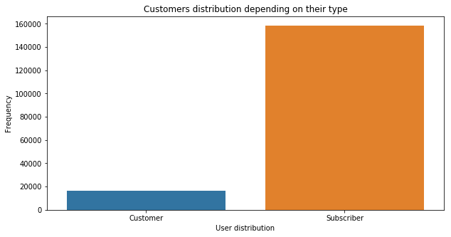

```python
title="Customers distribution depending on their type"
size=(10,5)
x_label= 'User distribution'
y_label= 'Frequency'
x= 'user_type'

countplot(df_copy, x, x_label, y_label, title, size)
```

**Observation**

The majority of the users are subscribers and the lower type are Customers

**Question**

what is the distribution of bike rides for each day?

**Visualization**

**Note**

in this cell i did not use the function countplot because I had to plot ordinal data that have a natural order. (days of the week)

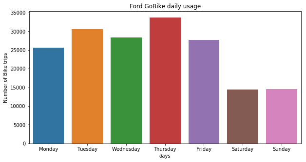

```python
# Weekday usage of the Ford Go bike system
day = ['Monday', 'Tuesday', 'Wednesday', 'Thursday', 'Friday', 'Saturday', 'Sunday']

plt.figure(figsize = (10,5))
plot = sns.countplot(data=df_copy , x='start_time_day' , order = day)
plt.xlabel('days')
plt.ylabel('Number of Bike trips')
plt.title("Ford GoBike daily usage")

plt.show()
```

**Observation**

**Question**

What is the distribution of bike rides for each hour?

**Visualization**

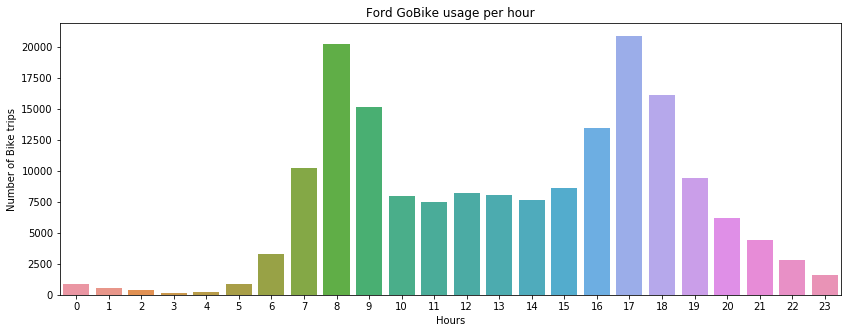

```python
title="Ford GoBike usage per hour"
size=(14,5)
x_label= 'Hours'
y_label= 'Number of Bike trips'
x= 'start_time_hour'

countplot(df_copy, x, x_label, y_label, title, size)
```

**Observation**

The top usage of bikes is during the morning hours of 8-9am, and in the afternoon hours of 5-6pm.

**Question**

What is the distribution of bike rides per minutes?

**Visualization**

```python
#function to plot hist in matplotlib :

def hist(dataset, x_, x_label, y_label, title, size, limits):
    plt.figure(figsize = size)
    df_copy[x_].hist(bins=60)
    plt.xlabel(x_label)
    plt.ylabel(y_label)
    plt.xlim(limits)
    plt.title(title)
    plt.show()
```

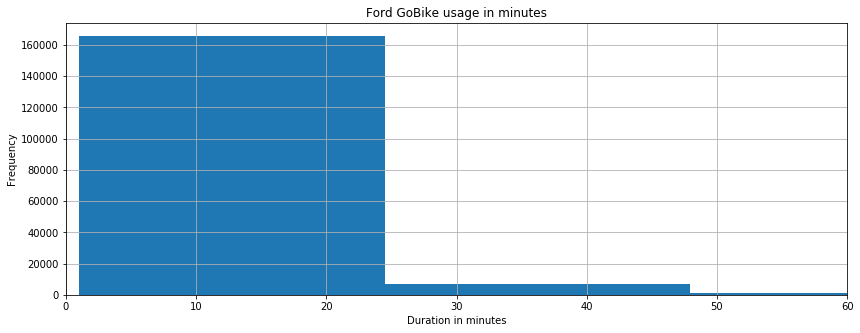

```python
x='duration_min'
xlabel='Duration in minutes'
ylabel='Frequency'
title ="Ford GoBike usage in minutes"
size= (14,5)
limits=0,60

hist(df_copy, x, xlabel, ylabel, title, size, limits)
```

**Observation**

the majority of the users go on bike trips for less than half an hour.

**Question**

What is the distribution of bike rides' ages?

**Visualization**

**Note**

For this cell I didn't use the function hist because I had to visualize the mean line on the histogram of users distribution by age

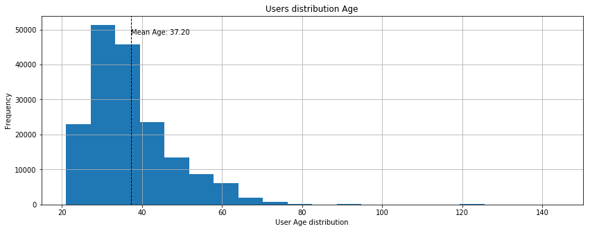

```python
plt.figure(figsize = (14,5))

df_copy['Age'].hist(bins= 20);

plt.xlabel('User Age distribution')
plt.ylabel('Frequency')
plt.title("Users distribution Age")
plt.axvline(df_copy['Age'].mean(), color='k', linestyle='dashed', linewidth=1)

min_ylim, max_ylim = plt.ylim()
plt.text(df_copy.Age.mean(), max_ylim*0.9, 'Mean Age: {:.2f}'.format(df_copy.Age.mean()))
plt.show()
```

**Observation**

the majority of the users' ages are between 22 and 39 with mean age = 37.

**Question**

Does the age variable have outliers?

**Visualization**

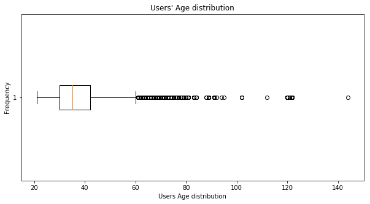

```python
plt.figure(figsize = (10,5))

plt.boxplot(df_copy['Age'], vert=False)

plt.xlabel('Users Age distribution')
plt.ylabel('Frequency')
plt.title("Users' Age distribution")

plt.show()
```

**Observation**

We have outliers in the age 120 and more than 140, which are not believable.

We also have alot of outliers between the ages of 60 and 80.

```python
#delete the users that have age beyond 100:

index_filter = df_copy[df_copy['Age'] > 100].index
df_copy.drop(index_filter, inplace=True)
```

```python
df_copy =df_copy.reset_index(drop=True)
```

```python
df_copy[df_copy['Age'] > 100]
```

|  | duration_sec | start_time | end_time | start_station_id | start_station_name | end_station_id | end_station_name | bike_id | user_type | member_birth_year | member_gender | bike_share_for_all_trip | Age | start_time_month | end_time_month | start_time_day | end_time_day | start_time_hour | end_time_hour | duration_min |
| --- | --- | --- | --- | --- | --- | --- | --- | --- | --- | --- | --- | --- | --- | --- | --- | --- | --- | --- | --- | --- |

**Test**

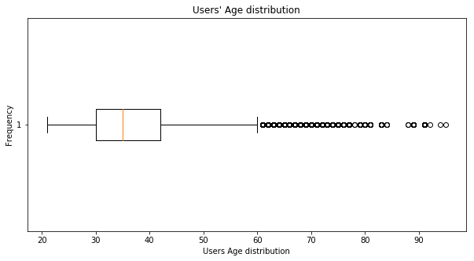

```python
plt.figure(figsize = (10,5))

plt.boxplot(df_copy['Age'], vert=False)

plt.xlabel('Users Age distribution')
plt.ylabel('Frequency')
plt.title("Users' Age distribution")

plt.show()
```

**Question**

What is the distribution for the bike share users on all Trips??

**Visualization**

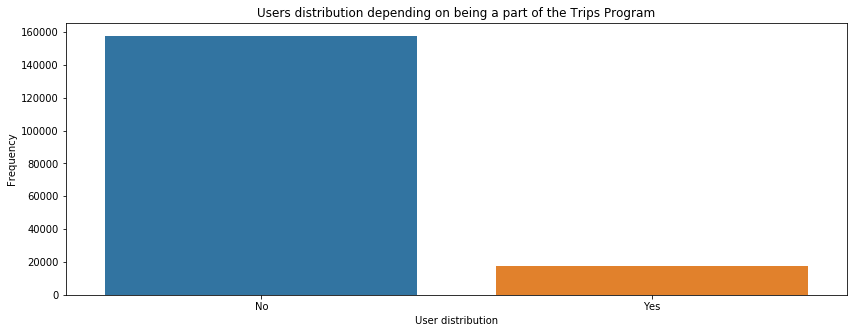

```python
title="Users distribution depending on being a part of the Trips Program"
size=(14,5)
x_label= 'User distribution'
y_label= 'Frequency'
x= 'bike_share_for_all_trip'

countplot(df_copy, x, x_label, y_label, title, size)
```

**Observation**

The majority of the users are not a part of the Trips Program

**Question**

What is the distribution for the bike users gender?

**Visualization**

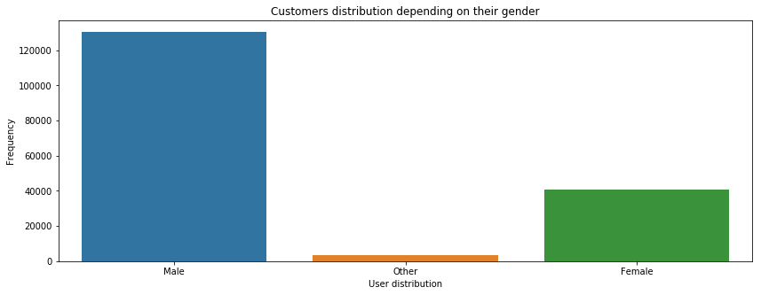

```python
title="Customers distribution depending on their gender"
size=(14,5)
x_label= 'User distribution'
y_label= 'Frequency'
x= 'member_gender'

countplot(df_copy, x, x_label, y_label, title, size)
```

**Observation**

The majority of the users are Male and the lowest are other.

### Discuss the distribution(s) of your variable(s) of interest. Were there any unusual points? Did you need to perform any transformations?

The majority of the users are subscribers and the lower type are Customers

The top usage of bikes is during the morning hours of 8-9am, and in the afternoon hours of 5-6pm.

the majority of the users go on bike trips for less than half an hour.

the majority of the users' ages are between 22 and 39 with mean age = 37.

We had outliers in the age 120 and more than 140, which are not believable.We also have alot of outliers between the ages of 60 and 80. So i had to delete the users that have age beyond 100 by filtering them and dropping them from the dataset.

The majority of the users are not a part of the Trips Program.

The majority of the users are Male and the lowest are other.

### Of the features you investigated, were there any unusual distributions? Did you perform any operations on the data to tidy, adjust, or change the form of the data? If so, why did you do this?

We got Age outliers for more than 100 years old. That was surprising.

In the distribution of duration, the majority of minutes charts were 30 minutes or less, which was surprising as well

## Bivariate Exploration

In this section, we will be investigating relationships between pairs of variables in the data.

**Question**

What is the relationship between days and number of trips depending on user type ?

**Visualization**

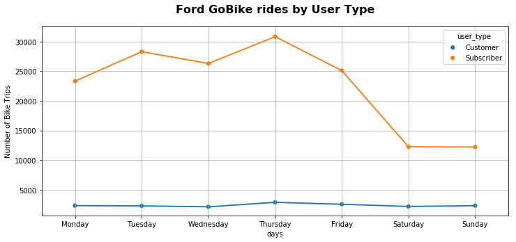

```python
# Customer Daily Usage vs. Subscriber Daily Usage
plt.figure(figsize=(12, 5))

df_user = df_copy.groupby(['start_time_day', 'user_type']).size().reset_index()

days = ['Monday', 'Tuesday', 'Wednesday', 'Thursday', 'Friday', 'Saturday', 'Sunday']

ax = sns.pointplot(data=df_user, x='start_time_day', y=0, hue = 'user_type', scale=.7, order = days);

plt.title('Ford GoBike rides by User Type', y=1.05, fontsize=16, fontweight='bold')
plt.xlabel('days')
plt.ylabel('Number of Bike Trips');
plt.grid()
```

**Obseravtion**

Customers have a very low usage of the bike share system with a small increase on Thursdays.

Subscribers are the opposite. The rate of bike riders are very high especially on Thursdays but it drops significantly on Saturdays and Sundays.

**Question**

What is the distribution of type of Customers based on their age?

**Visualization**

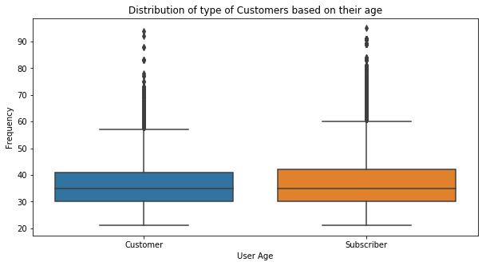

```python
#distribution of type of Customers based on their age

plt.figure(figsize = (10,5))

sns.boxplot(data=df_copy, x = "user_type", y='Age')

plt.xlabel('User Age')

plt.ylabel('Frequency')


plt.title("Distribution of type of Customers based on their age")

plt.show()
```

**Observation**

There are more Subscribers at the ages of >40 than Customers.

Customers are relatively younger than Subscribers.

**Question**

What is the relationship relation between ages and bike ride time ?

**Visualization**

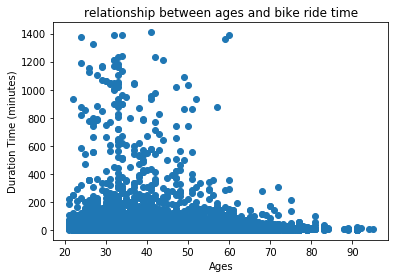

```python
# plotting relation between ages and bike ride time

plt.scatter(data=df_copy ,x='Age', y='duration_min' );
plt.xlabel('Ages')
plt.ylabel('Duration Time (minutes)');
plt.title('relationship between ages and bike ride time');
```

**Observation**

Age and Duration of bike rides are not correlated.

Younger ages tend to go on longer bike rides.

**Question**

What is the relationship between Age and Gender ?

**Visualization**

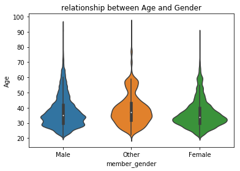

```python
# plotting the relationship between Age and Gender
sns.violinplot(data=df_copy, x='member_gender', y='Age',innner=None);
plt.title('relationship between Age and Gender');
```

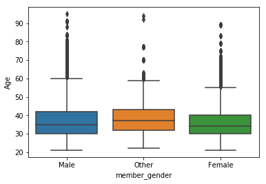

```python
# plotting box plot
sns.boxplot(data=df_copy, x='member_gender', y='Age');
```

**Observation**

Female riders are relatively younger than male riders, thus having a shorter IQR.

**Question**

How long is the duration of the trip for each gender in minutes?

**Visualization**

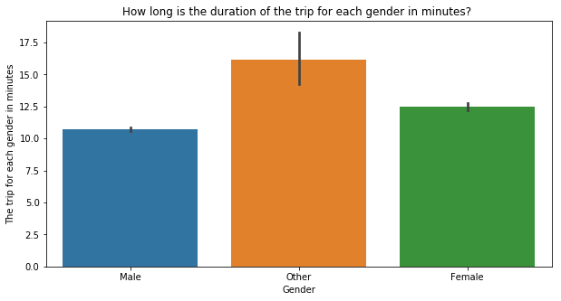

```python
plt.figure(figsize = (10,5))
sns.barplot(data = df_copy, x = "member_gender", y = "duration_min")
plt.xlabel('Gender')
plt.ylabel('The trip for each gender in minutes')
plt.title("How long is the duration of the trip for each gender in minutes? ")
plt.show()
```

**Observation**

Male users tend to go on shorter bike rides compared to other and female riders.

**Question**

How long is the duration of the trip for each user_type in minutes?

**Visualization**

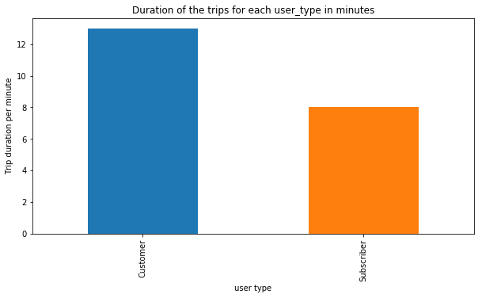

```python
plt.figure(figsize = (10,5))
df_copy.groupby('user_type')['duration_min'].median().sort_values(ascending=False).plot(kind='bar')
plt.xlabel('user type')
plt.ylabel('Trip duration per minute')
plt.title("Duration of the trips for each user_type in minutes")
plt.show()
```

**Observation**

user type of Customer tend to go on longer bike trips than user type of Subscriber.

**Question**

How is the distribution of start hour depending on user type ?

**Visualization**

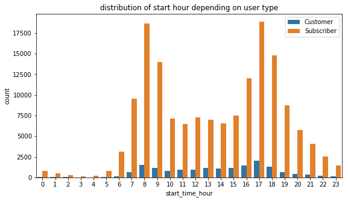

```python
plt.figure(figsize = [20, 5])
plt.subplot(1, 2, 1)
sns.countplot(data = df_copy, x = 'start_time_hour', hue = 'user_type')
plt.legend();
plt.title('distribution of start hour depending on user type');
```

**Observation**

More Subscribers take bike rides on the hours of 7:30-8am and 4-6pm.

### Talk about some of the relationships you observed in this part of the investigation. How did the feature(s) of interest vary with other features in the dataset?

Customers have a very low usage of the bike share system with a small increase on Thursdays.

Subscribers are the opposite. The rate of bike riders are very high especially on Thursdays but it drops significantly on Saturdays and Sundays.

There are more Subscribers at the ages of >40 than Customers.

Customers are relatively younger than Subscribers.

Age and Duration of bike rides are not correlated.

Younger ages tend to go on longer bike rides.

Female riders are relatively younger than male riders, thus having a shorter IQR.

Male users tend to go on shorter bike rides compared to other and female riders.

user type of Customer tend to go on longer bike trips than user type of Subscriber.

More Subscribers take bike rides on the hours of 7:30-8am and 4-6pm.

### Did you observe any interesting relationships between the other features (not the main feature(s) of interest)?

that subscribers are slightly older than customers on average but take much shorter/quicker ride

## Multivariate Exploration

In this section we will be creating plots of three or more variables to investigate the data even further.

**Question**

What is the Correlation between each variable in the dataset?

**Visualization**

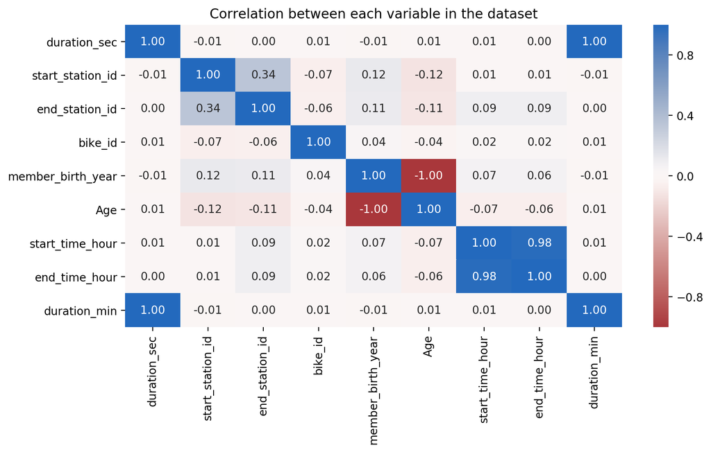

```python
plt.figure(figsize = (10,5), dpi = 200)
sns.heatmap(df_copy.corr(), annot = True, fmt = '.2f', cmap = 'vlag_r', center = 0)
plt.title("Correlation between each variable in the dataset")
plt.xticks(rotation = 90)
plt.legend(bbox_to_anchor=(1.05, 1), loc='upper left')

plt.show()
```

**Observation**

There is no Correlation for any variable with time ( duration_sec /duration_minutes)

There is a strong Correlation between end_time_hour and start_time_hour, so we can say that the time of renting the bikes can be useful in studying the marketing of the bikes in the company.

**Question**

What is the Correlation between numerical variables in the dataset ?

**Visualization**

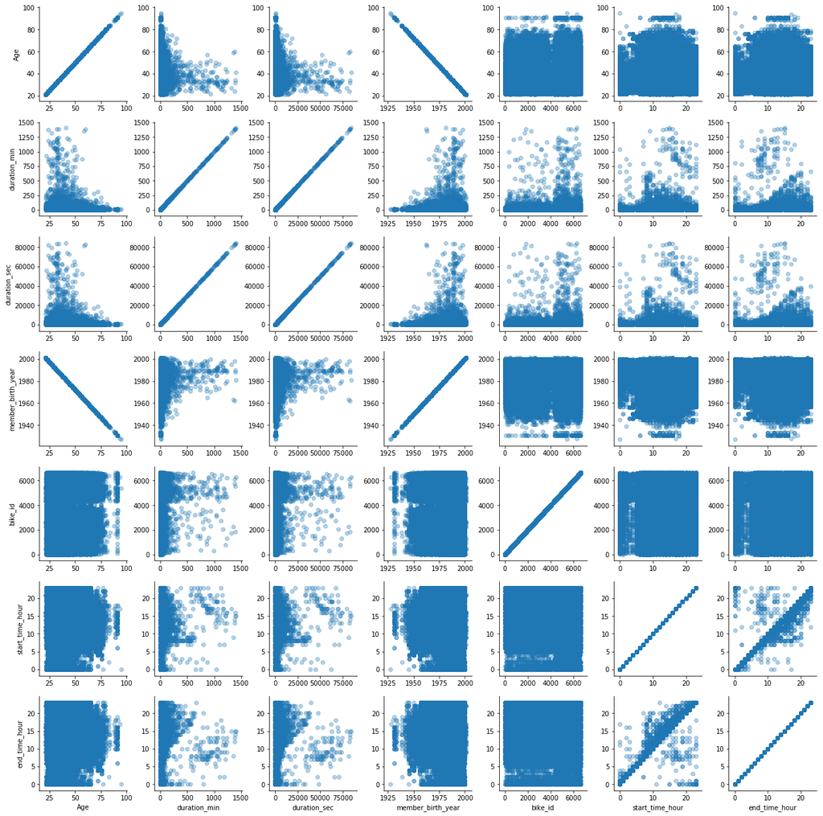

```python
test = ['Age', 'duration_min',"duration_sec", "member_birth_year", "bike_id", 'start_time_hour', 'end_time_hour']
temp = sns.PairGrid(data = df_copy, vars =test) ;
temp.map(plt.scatter, alpha = 1/3);
```

**Observation**

There is no Correlation for any variable with time ( duration_sec /duration_minutes)

There is a strong Correlation between end_time_hour and start_time_hour, so we can say that the time of renting the bikes can be useful in studying the marketing of the bikes in the company.

There is a negative Correlation between member_birth_year and age which is normal.

There is no significant Correlation for any variable with bike_id

**Question**

What is the average trip duration daily based on user type : customers and subscribers ?

**Visualization**

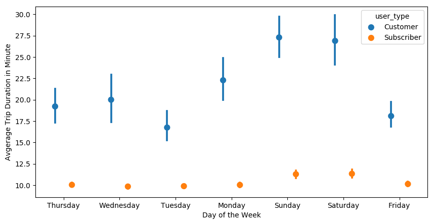

```python
plt.figure(figsize = (10,5), dpi = 100)
sns.pointplot(data=df_copy, x='start_time_day', y='duration_min', hue='user_type', dodge=0.3, linestyles="");
plt.xlabel('Day of the Week');
plt.ylabel('Avgerage Trip Duration in Minute');
```

**Observation**

It can be seen from the above plot that subscribers ride much shorter trips compared to customers on each day of the week.

### Talk about some of the relationships you observed in this part of the investigation. Were there features that strengthened each other in terms of looking at your feature(s) of interest?

The multivariate exploration strengthened some of the patterns discovered in the previous bivariate and univariate exploration, the relationship between the multiple variables plotted are visualized altogether and information are presented combined.

There is no Correlation for any variable with time ( duration_sec /duration_minutes)

There is a strong Correlation between end_time_hour and start_time_hour, so we can say that the time of renting the bikes can be useful in studying the marketing of the bikes in the company.

There is a negative Correlation between member_birth_year and age which is normal.

There is no significant Correlation for any variable with bike_id

It can be seen from the above plot that subscribers ride much shorter trips compared to customers on each day of the week.

### Were there any interesting or surprising interactions between features?

Most users were Male. This can be justified by the imbalanced number of female riders compared to male ones.

Most users were subscriber.

The distribution of duration was a bit surprising as the minutes charts were 30 minutes or less for most users.

The female distribution depending on their Age are younger than male.

## Conclusions

Renting a bike from theFord GoBike System Riding should be on top of the list if you have no plans for the holidays or even on weekdays. It is not only fun but also, it is a perfect activity for unwinding and keeping your body active.

The best part is that you do not have to worry about owning a bike. With rentals, you can easily access a bike for as long as you wish and have as much fun as you want.

There are two types of clients using this system: Subscribers and Customers. Subscribers are primarily daily commuters, having short trips to and from their destination which can be estimated as work or school, who rent a bike on weekdays at 8-9am and 5-6pm.

### Limitations for this project :

-Many null data points were present in the dataset, which had to be dealt with.

-Some users have 100 or more as their age, these were outliers that had to be cleaned.

**I will be storing the df_copy dataframe so i can use it in the presentation document**

```python
df_copy.to_csv('df_clean.csv', index=False)
```